# ST310 Course Project

Chris Chia, Mun Fai Chan, Zhen Yen Chan

26/04/21

# ST310 Course Project

We have obtained data from the Kaggle March Tabular Playground competition. The data consists of *anonymised features*, which correspond to a binary outcome variable; in other words the task is a **classification problem**. Although the data is anonymised, we are told that it relates to a problem in **insurance**.

We first read import key libraries and import the data

```r
library(tidyverse)
library(ggplot2)
library(tidymodels)
library(xgboost)
library(catboost)
library(tidyverse)
library(broom)
library(ggplot2)
library(arm)
library(car)
library(tidyr)
library(glmnet)
library(caret)
library(tidymodels)
library(pROC)
library(randomForest)
library(e1071)
library(arm)
df <- read.csv(file = "../data/train.csv")
cat(c("The dimensions of the array are :", dim(df)[1], ", ", dim(df)[2]))
```

```
The dimensions of the array are : 300000 ,  32
```

The dataset consists of 30 features, 19 *categorical variables* and 11 numerical variables. We will need to process these categorical variables in some manner, which we shall consider in the subequent section.

## Preprocessing

We first partition the data into our training and testing proportions

```r
rownames(df) = df$id
df = df[,-1] # remove id column
# the first 19 columns are categorical
cat_feats = 1:19
cont_feats <- 20:30
df[,cat_feats] <- lapply(df[,cat_feats], as.factor)
df$target <- as.factor(df$target)
```

```r
# subsample the data for faster model imputation
set.seed(1)
sam = sample(1:nrow(df), 4000)
df_sample = df[sam,]
# Partition data into train and test; test will be our oos data
set.seed(1)
df_split <- initial_split(df_sample, prop = 3/4)
df_train <- training(df_split)
df_test <- testing(df_split)
```

## Exploratory Data Analysis

### Univariate EDA

We observe that the univariate distributions of the *continuous* variables are all multi-modal and non-normal, but they are all normalised to the range of $[0, 1]$.

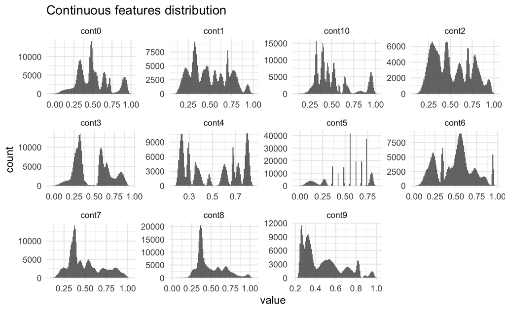

```r
df %>% pivot_longer(cols = starts_with("cont"), names_to  = "cont") %>%
   ggplot(aes(x = value))+
   geom_histogram(bins = 100, alpha = 0.85)+
   ggtitle("Continuous features distribution")+
   facet_wrap(cont~.,scales = "free")+
   theme_minimal()
```

For the distributions of categorical variables, we see that there are categories with substantially more observations in one category, and also categories with a high number of categories, which will be an issue to address in our preprocessing step.

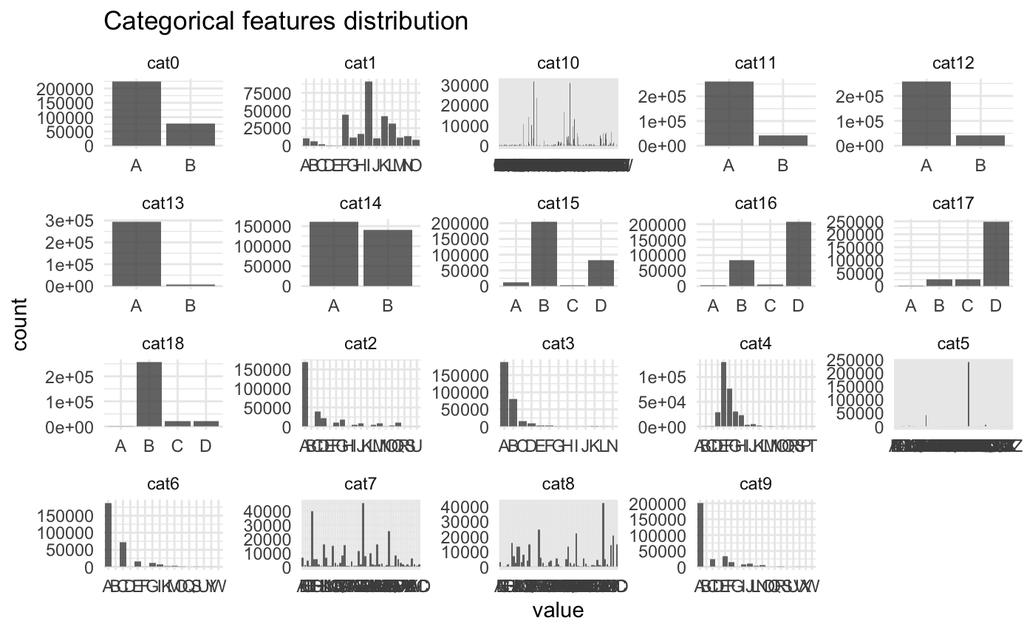

```r
df %>% pivot_longer(cols = contains(c("cat")), names_to  = "cat") %>%
   ggplot(aes(x = value))+
   geom_bar(alpha = 0.85)+
   ggtitle("Categorical features distribution")+
   facet_wrap(cat~.,scales = "free")+
   theme_minimal()
```

### Bivariate EDA

We group the continuous variables by the target and plot them as boxplots to see if there are any discernible differences by eye.

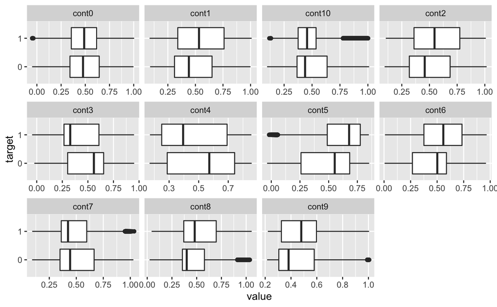

```r
cont.stacked <- gather(data=df[, c(cont_feats, 31)],-target,key="var",value="value")
p.cont <- ggplot(cont.stacked,aes(x=target,y=value),fill=factor(value)) + geom_boxplot() + coord_flip() + facet_wrap(~var, scales="free_x")
p.cont
```

We do the same with categorical variables.

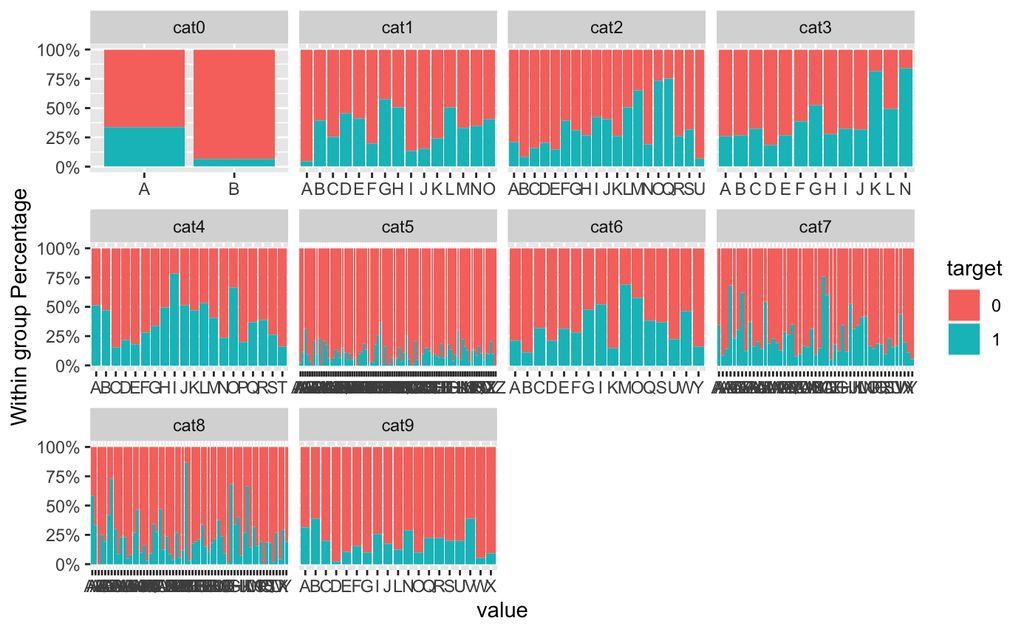

```r
g1 <- c(1:10,31)
g2 <- c(11:19,31)
cate.stacked1 <- gather(data=df[,g1],-target,key="var",value="value")
p.cate1 <- ggplot(cate.stacked1,aes(x=value,fill=target)) + geom_bar(position="fill") + scale_y_continuous(name = "Within group Percentage", labels = scales::percent) + facet_wrap(~var, scales="free_x")
cate.stacked2 <- gather(data=df[,g2],-target,key="var",value="value")
p.cate2 <- ggplot(cate.stacked2,aes(x=value,fill=target)) + geom_bar(position="fill") + scale_y_continuous(name = "Within group Percentage", labels = scales::percent) + facet_wrap(~var, scales="free_x")
p.cate1
```

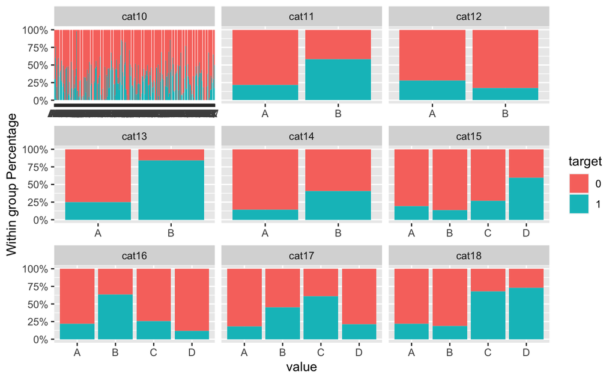

```r
p.cate2
```

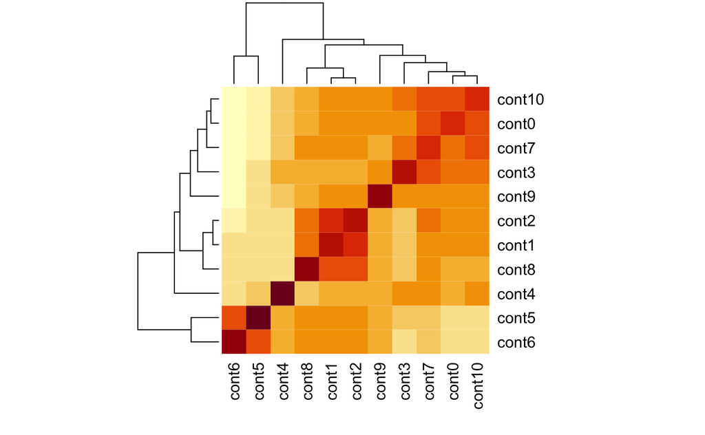

```r
df_num <- df[, cont_feats]
cor_matrix <- cor(df_num)
heatmap(cor_matrix)
```

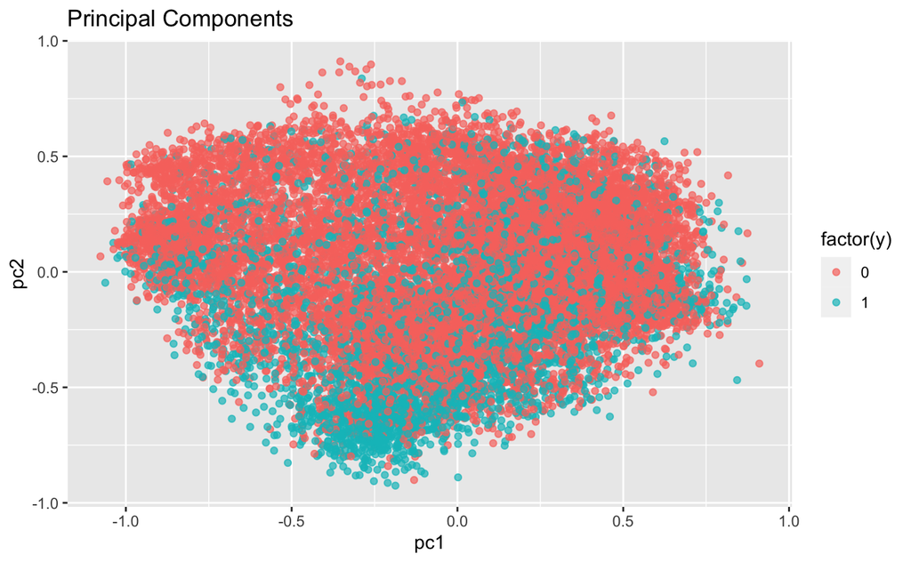

```r
pcs <- prcomp(df_num[,-length(df_num)])
set.seed(2021)
ind <- sample(1:dim(df)[1], 20000)
sample <- data.frame(pcs$x[ind,1], pcs$x[ind,2], df[ind, "target"])
names(sample) = c("pc1", "pc2", "y")
ggplot(sample) + geom_jitter(aes(x = pc1, y = pc2, colour = factor(y)),alpha=0.7) + ggtitle('Principal Components')
```

## Modelling

We first consider the most simple baseline: we predict all labels either 0 or 1. This illustrates the issue with the accuracy metric, the *baseline* accuracy could be potentially high, leading to a misleading result.

```r
# train-test
X_train = as.matrix(df_train[,grepl("cont", colnames(df_train))])
y_train = as.numeric(as.matrix(df_train$target))
X_test = as.matrix(df_test[,grepl("cont", colnames(df_train))])
y_test = as.numeric(as.matrix(df_test$target))
results = data.frame(train_acc = max(1 - mean(y_train), mean(y_train)),
                     train_auc = 0.5,
                     test_acc = max(1 - mean(y_test), mean(y_test)),
                     test_auc = 0.5,
                     row.names=c("baseline")
                     )
results
```

|  | train_acc | train_auc | test_acc | test_auc |
| --- | --- | --- | --- | --- |
| baseline | 0.745 | 0.5 | 0.728 | 0.5 |

## Logistic regression (baseline)

For our baseline model we select several variables based on our bivariate plots. We run logistic regression with a few variables (selected visually from plots)

```r
glm1 <- glm(target~cont3+cont4+cat13+cat18,data=df_train, family=binomial(link="logit"),control = list(maxit = 100))
summary(glm1)
```

```
Call:
glm(formula = target ~ cont3 + cont4 + cat13 + cat18, family = binomial(link = "logit"),
    data = df_train, control = list(maxit = 100))

Deviance Residuals:
    Min       1Q   Median       3Q      Max
-1.5707  -0.6702  -0.6021   0.3931   2.0095

Coefficients:
            Estimate Std. Error z value Pr(>|z|)
(Intercept)  -1.4821     1.0756  -1.378  0.16824
cont3        -0.6554     0.2276  -2.880  0.00398 **
cont4        -0.4772     0.2063  -2.313  0.02070 *
cat13B        1.8681     0.3346   5.584 2.36e-08 ***
cat18B        0.5581     1.0714   0.521  0.60243
cat18C        2.6081     1.0816   2.411  0.01590 *
cat18D        2.4342     1.0805   2.253  0.02427 *
---
Signif. codes:  0 ‘***’ 0.001 ‘**’ 0.01 ‘*’ 0.05 ‘.’ 0.1 ‘ ’ 1

(Dispersion parameter for binomial family taken to be 1)

    Null deviance: 3406.6  on 2999  degrees of freedom
Residual deviance: 2962.8  on 2993  degrees of freedom
AIC: 2976.8

Number of Fisher Scoring iterations: 4
```

```r
pred_train <- predict(glm1, df_train, type="response")
pred_test <- predict(glm1, df_test, type="response")

diagnosis <- function(train_pred, test_pred, train_true, test_true){
  train_classes <- ifelse(train_pred > 0.5, 1,0)
  test_classes <- ifelse(test_pred > 0.5, 1,0)
  acc1 <- mean(pred_classes_train == train_true)
  auc1 <- auc(roc(train_true, train_pred))
  acc2 <- mean(test_classes == test_true)
  auc2 <- auc(roc(test_true, test_pred))
  data.frame(train_acc=acc1, train_auc=auc1, test_acc = acc2, test_auc=auc2)
}


results["glm-small",] <- diagnosis(pred_train, pred_test, df_train$target, df_test$target)
results
```

[output not shown]

### SGD

We demonstrate a `from scratch’ Stochastic Gradient Descent routine for this classification problem

The logistic loss with a $\mathcal{L}^{2}$ penalty is given by:

$$l(\boldsymbol{\beta}) = -\sum_{i = 1}^{N} y_{i} log(p(x_{i} ; \boldsymbol{\beta})) + (1 - y_{i}) log(1 - p(x_{i} ; \boldsymbol{\beta})) = \sum_{i = 1}^{N} \left [ y_{i}log \left (\frac{p(x_{i} ; \boldsymbol{\beta})}{1 - p(x_{i} ; \boldsymbol{\beta})} \right) + log(1 - p(x_{i} ; \boldsymbol{\beta})) \right ]$$

$$l(\boldsymbol{\beta})= -\sum_{i = 1}^{N}\left [y_{i} \boldsymbol{\beta}^{T} x_{i} - log(1 + exp(\boldsymbol{\beta}^{T}x_{i})) \right ]$$
Then with the inclusion of the reularisation term:

$$l(\boldsymbol{\beta}) = -\sum_{i = 1}^{N} \left [y_{i} \boldsymbol{\beta}^{T} x_{i} - log(1 + exp(\boldsymbol{\beta}^{T}x_{i})) \right ] - \lambda \boldsymbol{\beta}^{T} \boldsymbol{\beta}$$

The gradient is given by:

$$\nabla(\boldsymbol{\beta}) = -\sum_{i = 1}^{N} \left [ y_{i} x_{i} - \frac{x_{i}exp(\boldsymbol{\beta}^{T} x_{i})}{1 + exp(\boldsymbol{\beta}^{T} x_{i})} \right] - \lambda 2\boldsymbol{\beta}$$

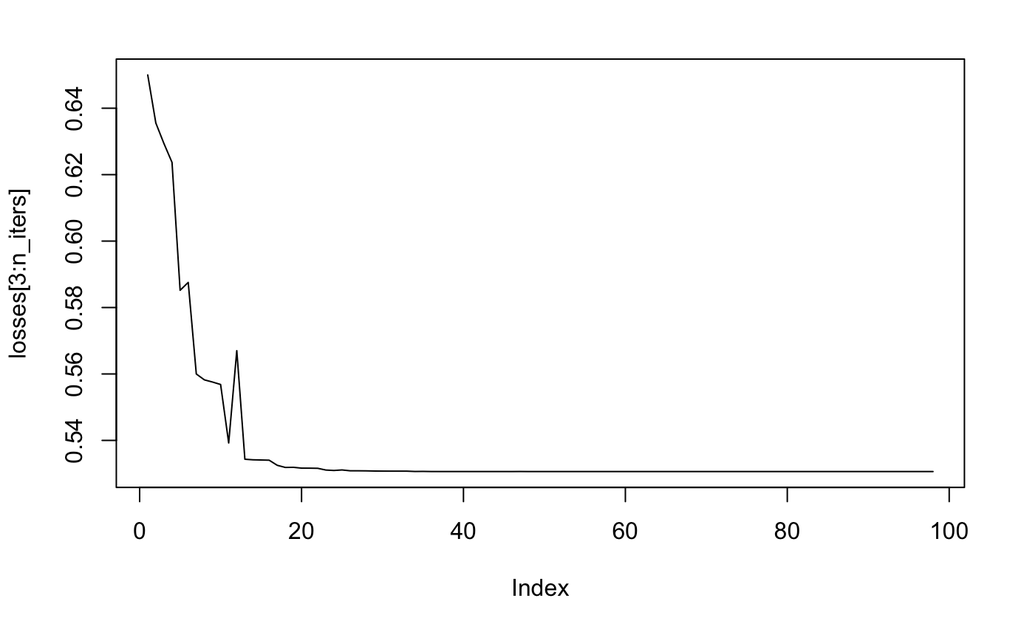

```r
# binary crossentropy / log-loss
log_loss <- function(x, y, betas, lambda){
  logits <- x %*% betas
  - (t(y) %*% logits - sum(log(1 + exp(logits))) + lambda * t(betas) %*% betas) / dim(x)[1]
}

# logistic regression gradients
gradients <- function(x, y, betas, lambda){
  logits <- x %*% betas
  - (t(x) %*% (y - exp(logits)/(1 + exp(logits)))) - lambda *2 * betas / dim(x)[1]
}

p = dim(X_train)[2]

lambda = 0
n_iters <- 100
init_step_size <- 1e-6

set.seed(2021)
beta_init <- matrix(rnorm(p),nrow=p)
beta_path <- matrix(rep(0, n_iters * p), nrow = n_iters, ncol=p)
beta_path[1,] = beta_init

last_grad <- grad <- gradients(X_train, y_train, beta_path[1,], lambda)
beta_path[2,] = beta_init - init_step_size * grad
grad <- gradients(X_train, y_train, beta_path[2,], lambda)

losses <- rep(0, n_iters)

for (i in 3:n_iters){
    step_size <- as.numeric(t(beta_path[i - 1,] - beta_path[i - 2,]) %*% (grad - last_grad) /
                    (t(grad - last_grad) %*% (grad - last_grad)))
    beta_path[i,] <- beta_path[i - 1,] - step_size * grad
    last_grad <- grad
    grad <- gradients(X_train, y_train, beta_path[i, ], lambda)
    losses[i] <- log_loss(X_train, y_train, beta_path[i,], lambda)
}
plot(losses[3:n_iters], type="l")
```

```r
pred_train <- as.numeric(1 / (1 + exp(-X_train %*% beta_path[100,])))
pred_test <- as.numeric(1 / (1 + exp(-X_test %*% beta_path[100,])))
# all 1s/ 0s, all 1s /0s test, SGD train acc, SGD val acc
roc1=roc(df_train$target, pred_train)
auc1=auc(roc1)
roc2=roc(df_test$target, pred_test)
auc2=auc(roc2)
results["sgd",] <- c(mean(((pred_train > 0.5) * 1) == y_train),
                  auc1,
                  mean(((pred_test > 0.5) * 1) == y_test),
                  auc2)
results
```

|  | train_acc | train_auc | test_acc | test_auc |
| --- | --- | --- | --- | --- |
| baseline | 0.7450000 | 0.5000000 | 0.728 | 0.5000000 |
| glm-small | 0.7923333 | 0.6878700 | 0.803 | 0.7033977 |
| sgd | 0.7580000 | 0.6740706 | 0.751 | 0.7082003 |

### Logistic Regression

We now run a logistic regression using all variables, using the `glm` package.

```r
glm2 <- glm(target~.,data=df_train, family=binomial(link="logit"),control = list(maxit = 100))
```

```r
pred_train <- predict(glm2, df_train, type="response")
```

```
prediction from a rank-deficient fit may be misleading
```

```r
glm2$xlevels = lapply(df[,cat_feats], levels)
pred_test <- predict(glm2, df_test, type="response")
```

```
prediction from a rank-deficient fit may be misleading
```

```r
pred_classes_train <- ifelse(pred_train > 0.5, 1,0)
pred_classes_test <- ifelse(pred_test > 0.5, 1,0)
acc1=mean(pred_classes_train == df_train$target)
roc1=roc(df_train$target, pred_train)
auc1=auc(roc1)
acc2=mean(pred_classes_test == df_test$target)
roc2=roc(df_test$target, pred_test)
auc2=auc(roc2)

results["glm-full",] <- data.frame(train_acc=acc1, train_auc=auc1, test_acc = acc2, test_auc=auc2)
results
```

[output not shown]

```r
anova(glm1, glm2, test="Chisq")
```

[output not shown]

### Logistic + Ridge

Given the issue of *high dimensionality*, we consider a regularised form of logistic regression. We use the `glmnet` package; in doing so we need to convert the data type into matrices.

```r
X_train = df_train[, -length(df_train)]
y_train <- df_train$target
X_test = df_test[, -length(df_test)]
y_test <- df_test$target
X_train = model.matrix(~., X_train)
X_test = model.matrix(~., X_test)


glm3 <- cv.glmnet(X_train, y_train, family="binomial"(link="logit"), alpha=0)
```

Test accuracy and ROC

```r
pred_train <- predict(glm3, X_train, type="response")
pred_test <- predict(glm3, X_test, type="response")
pred_classes_train <- ifelse(pred_train > 0.5, 1,0)
pred_classes_test <- ifelse(pred_test > 0.5, 1,0)
acc1=mean(pred_classes_train == df_train$target)
roc1=roc(df_train$target, pred_train)
```

```
Deprecated use a matrix as predictor. Unexpected results may be produced, please pass a numeric vector.Setting direction: controls < cases
```

```r
auc1=auc(roc1)
acc2=mean(pred_classes_test == df_test$target)
roc2=roc(df_test$target, pred_test)
```

```
Deprecated use a matrix as predictor. Unexpected results may be produced, please pass a numeric vector.Setting direction: controls < cases
```

```r
auc2=auc(roc2)

results["glm-ridge",] <- data.frame(train_acc=acc1, train_auc=auc1, test_acc = acc2, test_auc=auc2)
results
```

|  | train_acc | train_auc | test_acc | test_auc |
| --- | --- | --- | --- | --- |
| baseline | 0.7450000 | 0.5000000 | 0.728 | 0.5000000 |
| glm-ridge | 0.8523333 | 0.8975859 | 0.838 | 0.8839437 |

### Nonlinear Fit (Tree-based)

#### Random Forest

```r
control <- trainControl(method = "cv",
    number = 2,
    search = "grid")

ptm=proc.time()
set.seed(1)
rf1 <- train(target~.,
    data = df_train,
    method = "rf",
    metric = "Accuracy",
    trControl=control,
    importance=T,
    maxnodes=128,
    ntree=64)
time1=proc.time()-ptm
time1
```

```
   user  system elapsed
 43.052   1.025  49.192
```

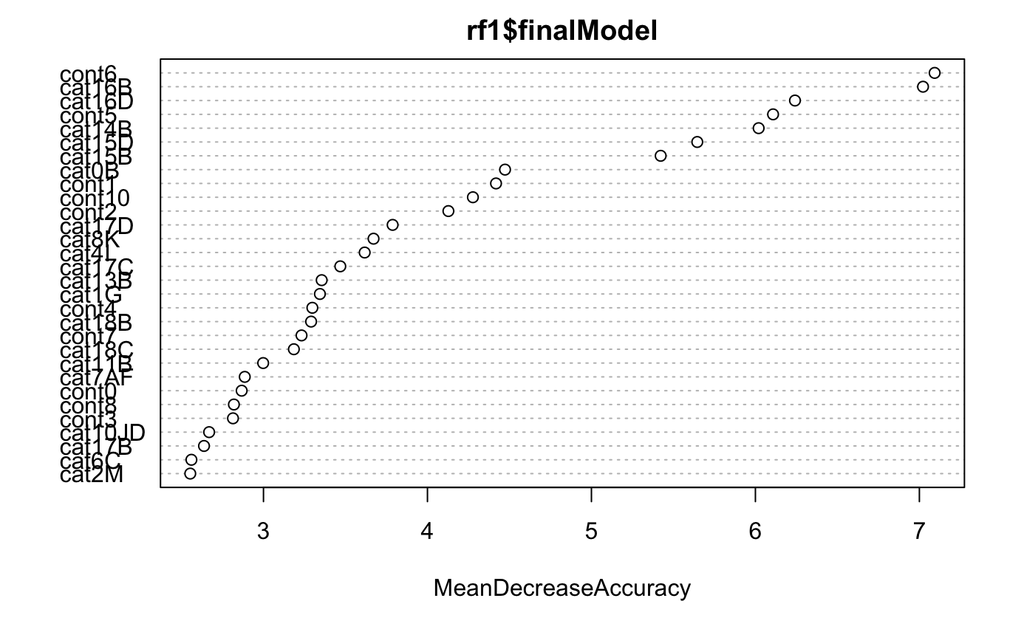

```r
#ls(rf1)
varImpPlot(rf1$finalModel, n.var=30, type=1)
```

```r
pred_train <- predict(rf1,df_train,type='prob')[,2]
pred_test <- predict(rf1, df_test, type='prob')[,2]
results["rf",] <- diagnosis(pred_train, pred_test, df_train$target, df_test$target)
results
```

[output not shown]

```r
X_train = df_train[,c(cat_feats, cont_feats)]
y_train = as.integer(df_train$target)
X_test = df_test[,c(cat_feats, cont_feats)]
y_test = as.integer(df_test$target)
rf <- randomForest(X_train, y_train, ntree=100)

importances <- data.frame(importance(rf))
importances$features <- rownames(importances)
n_features <- length(rownames(importances))
importances <- importances[order(importances$MeanDecreaseGini),]
importances$features <- factor(importances$features, level=importances$features)
N <- 20
ggplot(importances[(n_features-N+1):n_features,], aes(x=MeanDecreaseGini, y=features)) + geom_bar(stat="identity")
```

[output not shown]

```r
pred_train <- predict(rf, X_train, type="prob")[, 2]
pred_test <- predict(rf, X_test, type="prob")[, 2]
pred_classes_train <- ifelse(pred_train > 0.5, 1,0)
pred_classes_test <- ifelse(pred_test > 0.5, 1,0)
acc1=mean(pred_classes_train == df_train$target)
roc1=roc(df_train$target, pred_train)
auc1=auc(roc1)
acc2=mean(pred_classes_test == df_test$target)
roc2=roc(df_test$target, pred_test)
auc2=auc(roc2)

results["rf",] <- data.frame(train_acc=acc1, train_auc=auc1, test_acc = acc2, test_auc=auc2)
results
```

#### XGBoost

For completeness, we also consider the `xgboost` library for **gradient boosted decision trees**. Gradient Boosted Decision Trees

```r
dmy_train <- dummyVars("~.", data = df_train[,-length(df_train)])
dmy_test <- dummyVars("~.", data = df_test[,-length(df_test)])
X_train <- as.matrix(data.frame(predict(dmy_train,df_train)))
X_test <- as.matrix(data.frame(predict(dmy_test,df_test)))
y_train = as.integer(as.matrix(df_train$target))
y_test = as.integer(as.matrix(df_test$target))
bst <- xgboost(data = X_train, y_train, max_depth = 2, nround = 10,
               verbose=0,
               objective='binary:logistic')

pred_train <- predict(bst, X_train, type="response")
pred_test <- predict(bst, X_test, type="response")
pred_classes_train <- ifelse(pred_train > 0.5, 1,0)
pred_classes_test <- ifelse(pred_test > 0.5, 1,0)
acc1=mean(pred_classes_train == df_train$target)
roc1=roc(df_train$target, pred_train)
auc1=auc(roc1)
acc2=mean(pred_classes_test == df_test$target)
roc2=roc(df_test$target, pred_test)
auc2=auc(roc2)

results["xgb",] <- data.frame(train_acc=acc1, train_auc=auc1, test_acc = acc2, test_auc=auc2)
results
```

[output not shown]

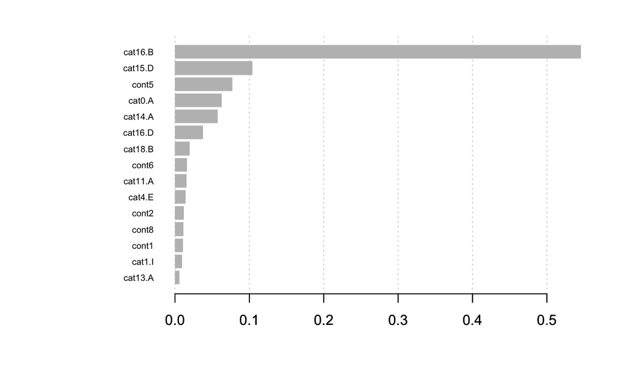

```r
importance_matrix <- xgb.importance(model=bst)
xgb.plot.importance(importance_matrix)
```

```r
library(shapr)

explainer <- shapr(X_train, bst)
```

```
Error: 'nafill' is not an exported object from 'namespace:data.table'
```

#### CatBoost

We also consider briefly examine the `catboost` library for **gradient boosted decision trees**. The catboost library has the advantage of learning an encoding for categorical variables, reducing the preprocessing that may be required. and is a popular machine learning model on Kaggle.

```r
# devtools::install_url('https://github.com/catboost/catboost/releases/download/v0.25.1/catboost-R-Darwin-0.25.1.tgz', INSTALL_opts = c("--no-multiarch", "--no-test-load"))

X_train = df_train[,c(cat_feats, cont_feats)]
y_train = as.integer(df_train$target)
X_test = df_test[,c(cat_feats, cont_feats)]
y_test = as.integer(df_test$target)

pool <- catboost.load_pool(X_train, y_train, cat_features = cat_feats)
model <- catboost.train(pool, params=list(depth = 8, iterations = 10, loss_function='Logloss', verbose=0))

pred_train <- catboost.predict(model, catboost.load_pool(X_train), prediction_type = 'Probability')
pred_test <- catboost.predict(model, catboost.load_pool(X_test), prediction_type = 'Probability')

pred_classes_train <- ifelse(pred_train > 0.5, 1,0)
pred_classes_test <- ifelse(pred_test > 0.5, 1,0)
acc1=mean(pred_classes_train == df_train$target)
roc1=roc(df_train$target, pred_train)
auc1=auc(roc1)
acc2=mean(pred_classes_test == df_test$target)
roc2=roc(df_test$target, pred_test)
auc2=auc(roc2)

results["catboost",] <- data.frame(train_acc=acc1, train_auc=auc1, test_acc = acc2, test_auc=auc2)
results
```

|  | train_acc | train_auc | test_acc | test_auc |
| --- | --- | --- | --- | --- |
| baseline | 0.7450000 | 0.5000000 | 0.728 | 0.5000000 |
| glm-ridge | 0.8523333 | 0.8975859 | 0.838 | 0.8839437 |
| glm-full | 0.8013333 | 0.7974558 | 0.590 | 0.5433904 |
| xgb | 0.8390000 | 0.8628396 | 0.827 | 0.8627156 |
| catboost | 0.8823333 | 0.9206024 | 0.836 | 0.8577489 |
| rf | 0.9770000 | 0.9421164 | 0.836 | 0.8716770 |
| glm-small | 0.9770000 | 0.6878700 | 0.803 | 0.7033977 |

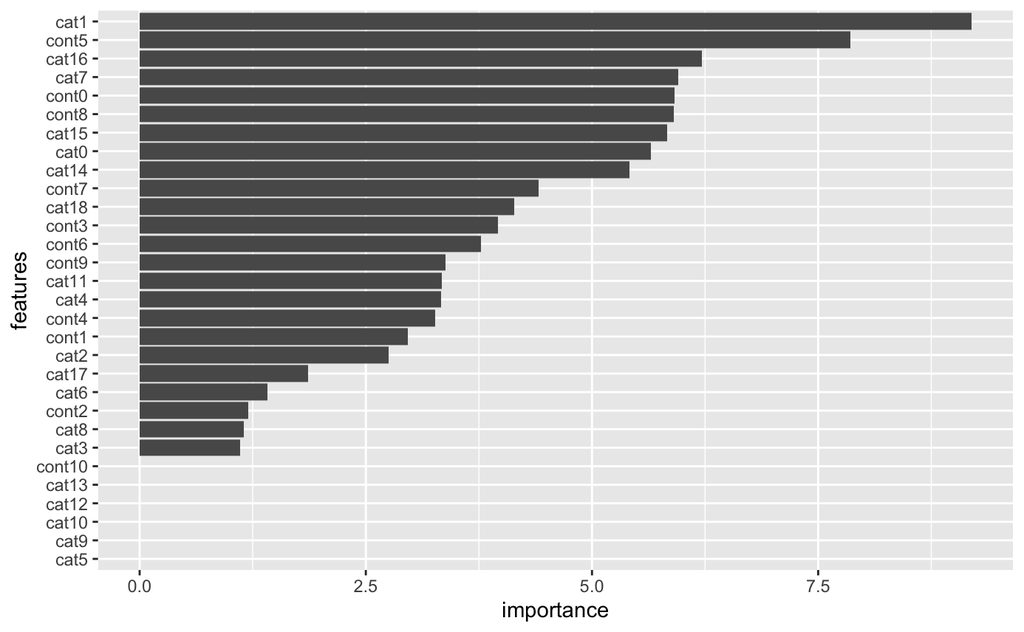

```r
feat_importance <- catboost.get_feature_importance(model, pool)
importances <- data.frame(feat_importance[order(feat_importance, decreasing=FALSE),])
importances$features = rownames(importances)
names(importances) <- c("importance","features")
importances$features <- factor(importances$features, level=importances$features)
ggplot(importances, aes(x=importance, y=features)) + geom_bar(stat="identity")
```

```r
lr_mod <-
  logistic_reg() %>%
  set_engine("glmnet")
lr_fit <- lr_mod %>% fit(target ~., data=df_train)


# df_train <- recipe( ~ ., data = df_train)
# df_train <- df_train %>% mutate(original = cat0)
# ref_cell <-
#   df_train %>%
#   step_dummy(cat0) %>% df_train
#
# df_train %>% mutate(across(starts_with("cat"), as.factor))
#
#
# dummies <- rec %>%
#   step_dummy(cat0) %>%
#   prep(training = df_train)
#

#
# df_train$target = as.factor(df_train$target)
#
# rec <- recipe(target ~., data = df_train)
#
# flights_wflow <-
#   workflow() %>%
#   add_model(lr_mod) %>%
#   add_recipe(rec)
#
# flights_fit <-
#   flights_wflow %>%
#   fit(data = df_train)
```

## Links

- https://www.kaggle.com/frankmollard/h2o-ml-ensemble
- https://www.guru99.com/r-random-forest-tutorial.html
- https://christophm.github.io/interpretable-ml-book/pdp.html

## Bibliography

Efron, Bradley and Hastie, Trevor. 2016. “Computer Age Statistical Inference.” Cambridge University Press.

Hastie, T. and Tibshirani, R. and Friedman, J.H. 2009. *The Elements of Statistical Learning: Data Mining, Inference, and Prediction*. Springer.

James, Gareth, Daniela Witten, Trevor Hastie, and Robert Tibshirani. 2017. “An Introduction To Statistical Learning.” Springer.